# Finding high achieving students for tech companies

## Purpose

Providing our client from the biotech industry with the most qualified schools that fulfill their criterias of recruitment.

## How:

1. Determine the best schools for our client, we need to set a bar on what determines a "top school".
2. Use College ScoreCard dataset.
3. Set our dependent variable to be **earnings** after graduation.
4. We will then look at how our other independent variables influence the earnings.

## Selecting predictors.

```
- Average SAT math and ACT scores
- Schools admission rate.
- Graduation rate.
- Pell Grant recipent
- Percentage of students who received a 4 year degree in STEM fields.
```

## Data cleaning.

```
- Removing rows containing empty entries
- Remove rows with any values
- Remove rows with privacy supressed
- Turn the structure of the columns from factors to numerics.
```

## 3 tiers of earning

- top tier > $75k
- middle tier = $30k - 75k
- low tier < $30k

## Random Forest variance importance

```
##                         %IncMSE IncNodePurity
## SATMT75               15.032319      22.45105
## ACTMT75               15.773562      20.21705
## ADM_RATE              13.567111      23.07322
## COMP_ORIG_YR4_RT       7.826030      12.97503
## PELL_COMP_ORIG_YR6_RT  6.219001      11.55428
```

#### find best features to predict the future earnings

## Multiple linear regression

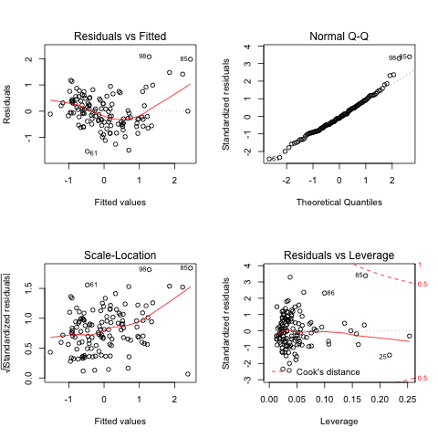

## Multiple linear regression coefficients, MSE and R-square

#### Coefficients

```
##           (Intercept)               SATMT75               ACTMT75
##         -4.646350e-16          2.517286e-01          3.705993e-01
##              ADM_RATE PELL_COMP_ORIG_YR6_RT      COMP_ORIG_YR4_RT
##         -1.391154e-01         -3.840951e-01          3.259766e-01
```

#### MSE

```
## [1] 0.3939347
```

#### R-square

```
##             R_squared_summary
## Top Tier            0.6029138
## Middle Tier         0.6168404
## Low Tier            0.5795355
```

## Ridge regression

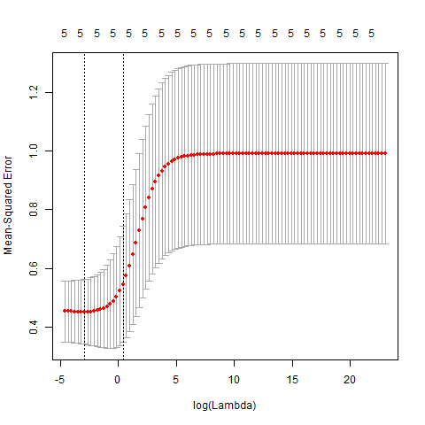

## Ridge regression coefficients

#### coefficients

```
## 6 x 1 sparse Matrix of class "dgCMatrix"
##                                1
## (Intercept)            .
## SATMT75                0.2530749
## ACTMT75                0.3483071
## ADM_RATE              -0.1614524
## COMP_ORIG_YR4_RT       0.2500293
## PELL_COMP_ORIG_YR6_RT -0.3077931
```

## Ridge MSE

```
## [1] 0.397438
```

## Observations:

- (+) relationship between future earnings and SAT math, ACT scores and graduation rate.
- (-) relationship between future earnings with admission rate and pell grant recipients.
- the less schools they admit, the higher the earnings are.
- **Pell-grants** come from a more disadvantaged family, lack of resources. People who don’t receive pell grants have more resources in support, which relates to higher earnings in the future.

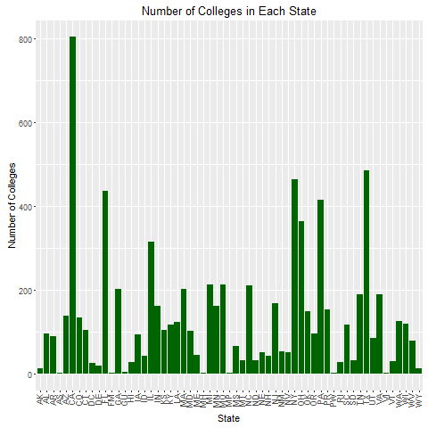

## Biology schools

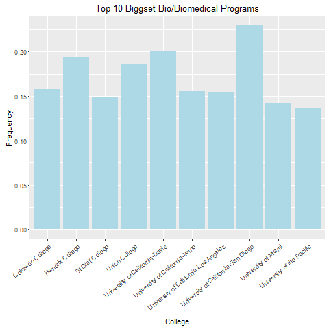

## Biology schools

```
##                                  INSTNM PCIP26
## 1    University of California-San Diego 0.2294
## 2        University of California-Davis 0.2004
## 3                       Hendrix College 0.1942
## 4                         Union College 0.1855
## 5                      Colorado College 0.1582
## 6       University of California-Irvine 0.1554
## 7  University of California-Los Angeles 0.1549
## 8                       St Olaf College 0.1497
## 9                   University of Miami 0.1420
## 10            University of the Pacific 0.1360
```